# Effects of Weather Events on Public Health and Property Damage

## Synopsis

This document reports the weather events that have the most effects on public health and property damage. The data comes from the U.S. National Oceanic and Atmospheric Administration’s (NOAA) storm database. To analyze health effects, the total number of fatalaties and total number of injuries are ranked from highest to lowest. The top 10 weather events were graphed for injuries and fatalities. Total health effects were calculated by adding fatalities plus injuries. The top 20 weather events causing effects on public health are presented. A similar approach was used to determine the top 10 weather events causing property and crop damage.

This data shows that tornadoes have the greatest effect on fatalities, injuries and property damage.

## Data Processing

### R code for data processing health effects

```r
  library(R.utils)
```

```r
  library(reshape2)
  library(ggplot2)
  library(grid)
  library(gridExtra)
  options(rpubs.upload.method="internal")

# Uncompress and get data
  #bunzip2("repdata_data_StormData.csv.bz2")
  Data<-read.csv("repdata_data_StormData.csv")
  Data$EVTYPE<- gsub("THUNDERSTORM WIND", "THUNDERSTORM",Data$EVTYPE)
  Data$EVTYPE<- gsub("THUNDERSTORM WINDS", "THUNDERSTORM",Data$EVTYPE)

#Aggregate inuries and fatalities by event type
  healthEffects<- melt(Data[,c(8,23,24)], id.var="EVTYPE")
  healthEffects<-aggregate(value ~ EVTYPE + variable, data=healthEffects, sum, na.rm=TRUE)
  healthEffects<-healthEffects[order(-healthEffects$value),]
  healthEffects<-dcast(healthEffects, EVTYPE ~ variable, sum)
  healthEffects<-healthEffects[order(-healthEffects$FATALITIES, -healthEffects$INJURIES),]
  healthEffects$TOTAL<- apply(healthEffects[, c("FATALITIES","INJURIES")], 1,sum)
  names(healthEffects)<-c("Event", "Fatalities", "Injuries", "Total")

# Get top causes of fatalities, injuries, and combined
  Fatalities<-healthEffects[,c(1,2)]
  Fatalities<-Fatalities[order(-Fatalities$Fatalities),]
  Fatalities<-Fatalities[1:10,]
  Injuries<-  Injuries<-healthEffects[,c(1,3)]
  Injuries<-Injuries[order(-Injuries$Injuries),]
  Injuries<-Injuries[1:10,]
  Total <-  Total<-healthEffects[,c(1,4)]
  Total <-Total [order(-Total$Total),]
  Total<-Total[1:20,]

# Get ordered list of events to arrange data on graph
  fatalLevels <-Fatalities$Event
  injurLevels<-Injuries$Event
  totalLevels<- Total$Event
```

```r
#Aggregate property damage and crop damage by event type
  econCons<- melt(Data[,c(8,25,27)], id.var="EVTYPE")
  econCons<-aggregate(value ~ EVTYPE + variable, data=econCons, sum)
  econCons<-econCons[order(-econCons$value),]
  econCons<-dcast(econCons, EVTYPE ~ variable, sum)
  econCons<-econCons[order(-econCons$PROPDMG, -econCons$CROPDMG),]
  econCons$TOTAL<- apply(econCons[, c("PROPDMG","CROPDMG")], 1,sum)
  names(econCons)<-c("Event", "Property", "Crop", "Both")

  # Get top 10 causes of Property, Crop, and combined
  Property<-econCons[,c(1,2)]
  Property<-Property[order(-Property$Property),]
  Property<-Property[1:10,]
  Crop<-  Crop<-econCons[,c(1,3)]
  Crop<-Crop[order(-Crop$Crop),]
  Crop<-Crop[1:10,]
  Both <-  Both<-econCons[,c(1,4)]
  Both <-Both [order(-Both$Both),]
  Both<-Both[1:20,]

  # Get ordered list of events to arrange data on graph
  propLevels <-Property$Event
  cropLevels<-Crop$Event
  bothLevels<- Both$Event
```

### R code for making graphs and setting parameters

This makes use of ggplot2, grid.extra packages

```r
 ### Data was prepared for data presentation with ggplot2
  params<- function(x){theme(axis.text.x= element_text(size= 8, , angle=45, vjust = 1, hjust= 1, color="black")) +
    theme(axis.text.y = element_text(size= 8, color="black")) +
    theme(plot.title = element_text(size= 14, color="black")) +
    theme(axis.title.x = element_text(size=8),axis.title.y  = element_text(size=12)) +
    theme(legend.title = element_text(size=9)) +
    theme(legend.text = element_text(size = 9))}

## Generate plots for health effects
# Plot number of fatalities by event type
  plotFatalities <- ggplot(data=Fatalities, aes(x=factor(Event, levels = paste(fatalLevels)), y=Fatalities)) +
  geom_bar(stat="identity", fill= "#990066", colour="black")  + ggtitle("Fatalities by Weather Event") +
    xlab(NULL) + ylab("Number of Fatalities") + params(plotFatalities)

# Plot number of injuries by event type
  plotInjuries <- ggplot(data=Injuries, aes(x=factor(Event, levels = paste(injurLevels)), y=Injuries)) +
  geom_bar(stat="identity", fill= "#336699", color="black")  + ggtitle("Injuries by Weather Event") +
    xlab(NULL) + ylab("Number of Injuries") + params(plotInjuries)

# Plot total number of effects by event type
  plotTotal <- ggplot(data=Total, aes(x=factor(Event, levels = paste(totalLevels)), y=Total)) +
  geom_bar(stat="identity", fill= "#006633", color="black")  + ggtitle("Total Health Effects by Weather Event") +
    xlab(NULL) + ylab("Total Health Effects") + params(plotTotal)

  # Plot amount of property damage by event type
  plotProperty <- ggplot(data=Property, aes(x=factor(Event, levels = paste(propLevels)), y=Property)) +
  geom_bar(stat="identity", fill= "#993333", colour="black")  + ggtitle("Property Damage by Weather Event") +
    xlab(NULL) + ylab("Property Damage") + params(plotProperty)

  # Plot amount of Crop damage by event type
  plotCrop <- ggplot(data=Crop, aes(x=factor(Event, levels = paste(cropLevels)), y=Crop)) +
  geom_bar(stat="identity", fill= "#CC9900", colour="black")  + ggtitle("Crop Damage by Weather Event") +
  xlab(NULL) + ylab("Crop Damage") + params(plotCrop)

  plotBoth<-ggplot(data=Both, aes(x=factor(Event, levels= paste(bothLevels)), y= Both))+
    geom_bar(stat="identity", fill= "#669933", colour="black")  + ggtitle("Total Economic Consequences by Weather Event") +
    xlab(NULL) + ylab("Total Damage") + params(plotCrop)
```

## Results

### Public Health effects of various weather events

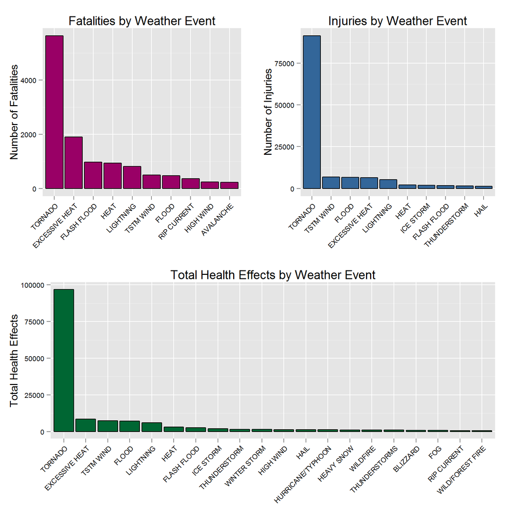

### Figure 1

This figure demonstrates the health effects of various weather events. The top two panels demonstrate Fatalities and Injuries by weather events. The top ten weather events are listed in order from left to right. The bottom panel combines fatalities and injuries and lists the top 20 weather events causing health effects.

### Economic consequences of various weather events

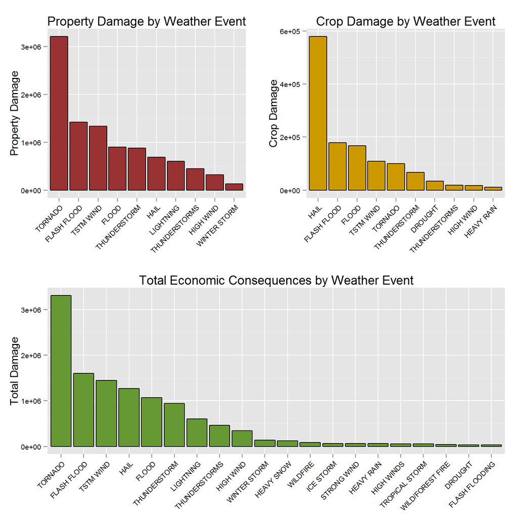

### Figure 2

This figure demonstrates the economic consequences of various weather events. The top two panels demonstrate Property Damage and Crop Damage caused by weather events. The top ten weather events are listed. The bottom panel combines property and crop damage and lists the top 20 weather events causing total damage.